# Cyclistic Bikeshare - Case Study

This case study is originally based on “[Sophisticated, Clear, and Polished’: Divvy and Data Visualization](https://artscience.blog/home/divvy-dataviz-case-study)” written by Kevin Hartman. We will be using [Divvy Dataset](https://divvy-tripdata.s3.amazonaws.com/index.html) from December 2021 to November 2022 for the case study as part of the Google Data Analytics Professional Certification Program. The data has been made available by Motivate International Inc. under this [license](https://ride.divvybikes.com/data-license-agreement). Due to data-privacy, any personally-identifiable information has been removed/encrypted.

### Scenario

You are a junior data analyst working in the marketing analyst team at Cyclistic, a bike-share company in Chicago. The director of marketing believes the company’s future success depends on maximizing the number of annual memberships. Therefore, your team wants to understand how casual riders and annual members use Cyclistic bikes differently. From these insights, your team will design a new marketing strategy to convert casual riders into annual members. But first, Cyclistic executives must approve your recommendations, so they must be backed up with compelling data insights and professional data visualizations.

### Deliverables:

1. A clear statement of business task
2. A description of all data source used
3. Documentation of any cleaning or manipulation of data
4. A summary of the analysis
5. Supporting visualization and key findings
6. Top three recommendations based on your analysis

# Phase 1: Ask

In this phase, the problem and objectives of our case study and its desired outcome are stated.

##### **Business task:**

How do Annual Members and Casual Riders use Cyclistic bikes differently?

# Phase 2: Prepare

In the this phase, we check the data being used and its limitations.

##### Limitations of the data:

- We cannot know if a casual member is repeteadly using bike share facility as we do not have that access.
- The data has some negative ride length and ride length less than 1 minutes, we have no insight of such cases.

##### Load necessary packages

```r
library("tidyverse") # tidyverse is an opinionated collection of R packages designed for data science.
library("lubridate") # package for dealing with dates
```

##### Collect csv files and merge multiple file into single file

Before merging multiple files into a single file, I already check that the number of columns, column names, and column data types are consistent.

```r
list_of_files <- list.files(
    path = "E:/Resources/case_studies/bikeshare/datasets/bikeshare-dec21-to-nov22",
    pattern = "csv",
    full.names = TRUE
)
all_trips <- readr::read_csv(list_of_files)
```

##### Inspect the new dataframe

Now we got big dataframe as all_trips

```r
glimpse(all_trips)
```

```
## Rows: 5,733,451
## Columns: 13
## $ ride_id            <chr> "46F8167220E4431F", "73A77762838B32FD", "4CF4245205…
## $ rideable_type      <chr> "electric_bike", "electric_bike", "electric_bike", …
## $ started_at         <dttm> 2021-12-07 15:06:07, 2021-12-11 03:43:29, 2021-12-…
## $ ended_at           <dttm> 2021-12-07 15:13:42, 2021-12-11 04:10:23, 2021-12-…
## $ start_station_name <chr> "Laflin St & Cullerton St", "LaSalle Dr & Huron St"…
## $ start_station_id   <chr> "13307", "KP1705001026", "KA1504000117", "KA1504000…
## $ end_station_name   <chr> "Morgan St & Polk St", "Clarendon Ave & Leland Ave"…
## $ end_station_id     <chr> "TA1307000130", "TA1307000119", "13137", "KP1705001…
## $ start_lat          <dbl> 41.85483, 41.89441, 41.89936, 41.89939, 41.89558, 4…
## $ start_lng          <dbl> -87.66366, -87.63233, -87.64852, -87.64854, -87.682…
## $ end_lat            <dbl> 41.87197, 41.96797, 41.93758, 41.89488, 41.93125, 4…
## $ end_lng            <dbl> -87.65097, -87.65000, -87.64410, -87.63233, -87.644…
## $ member_casual      <chr> "member", "casual", "member", "member", "member", "…
```

##### Rename column member_casual to member_type for self-explanatory name

```r
all_trips <- all_trips %>%
  rename(member_type = member_casual) %>%
  rename(bike_type = rideable_type)
```

##### **Description of all data source used:**

- We have used all 12 ‘.csv’ files.
- We renamed column name member_casual to member_type and rideable_type to bike_type for self-explanatory name.
- We take a look on `all_trips` and understand what data is provided.

# Phase 3: Process

In this phase, we will clean the data and make it ready for analysis

##### **Documentation of any cleaning or manipulation of data:**

##### Remove unused columns

```r
all_trips_v2 <- subset(all_trips, select = -c(start_station_name, start_station_id, end_station_name, end_station_id, start_lat, start_lng, end_lat, end_lng))
```

##### There are few problems to fix in this data:

1. The data can only be aggregated at the ride-level, which is too granular. We will want to add some additional columns of data – such as day, month, year – that provide additional opportunities to aggregate the data.
2. We will want to add a calculated field for length of ride since the data did not have the “trip_duration” column. We will add”ride_length” to the entire dataframe for consistency.
3. There are some rides where trip_duration shows up as negative, including several hundred rides where Divvy took bikes out of circulation for Quality Control reasons. We will want to delete these rides.

##### Add columns that list the date, year, month, day of each ride, and ride length in seconds

This will allow us to aggregate ride data for each month, quarter, day, or year … before completing these operations we could only aggregate at the ride level.

```r
all_trips_v2$date <- date(all_trips_v2$started_at)

all_trips_v2$year <- year(all_trips_v2$date)
all_trips_v2$month <- month(all_trips_v2$date)
all_trips_v2$day <- day(all_trips_v2$date)
all_trips_v2$day_of_week <- wday(all_trips_v2$date, label = TRUE, abbr = FALSE)

all_trips_v2$ride_length <- difftime(all_trips_v2$ended_at, all_trips_v2$started_at)
```

##### Remove bike_type “docked_bike” from dataframe

The bike_type “docked_bike” designates bikes that were taken out of circulation by Cyclistic to assess for quality control. There are also various trips where ride_length returns a negative duration. These entries need to be removed from our dataframe.

```r
all_trips_v2 <- all_trips_v2[!(all_trips_v2$bike_type == "docked_bike" | all_trips_v2$ride_length<0),]
```

##### Inspect dataframe for missing values

```r
all_trips_v2 %>%
  sapply(function(x) sum(is.na(x)))
```

```
##     ride_id   bike_type  started_at    ended_at member_type        date
##           0           0           0           0           0           0
##        year       month         day day_of_week ride_length
##           0           0           0           0           0
```

# Phase 4: Analyze

In this phase, we will analyze the cleaned data

##### **Summary of the analysis:**

##### Number of rides and ride length average for casual riders vs. member riders:

```r
all_trips_v2 %>%
  group_by(member_type) %>%
  summarise(number_of_rides = n(), average_ride_length = mean(ride_length))
```

| member_type | number_of_rides | average_ride_length |
| --- | --- | --- |
| casual | 2166344 | 1287.2690 secs |
| member | 3386530 | 762.5375 secs |

##### Number of rides and ride length average by each day for casual riders vs. member riders:

```r
all_trips_v2 %>%
  group_by(day_of_week, member_type) %>%
  summarise(number_of_rides = n(), average_ride_length = mean(ride_length))
```

| day_of_week | member_type | number_of_rides | average_ride_length |
| --- | --- | --- | --- |
| Sunday | casual | 355908 | 1460.6215 secs |
| Sunday | member | 390487 | 842.8941 secs |
| Monday | casual | 257559 | 1295.4847 secs |
| Monday | member | 476931 | 736.4146 secs |
| Tuesday | casual | 246187 | 1172.8889 secs |
| Tuesday | member | 518657 | 728.8662 secs |
| Wednesday | casual | 261600 | 1129.5208 secs |
| Wednesday | member | 537743 | 723.9585 secs |
| Thursday | casual | 293543 | 1160.6411 secs |
| Thursday | member | 540341 | 737.9848 secs |

[output cut: 4 more lines]

##### Number of rides and average ride length by member type and tyoe of bike:

```r
all_trips_v2 %>%
  group_by(member_type, bike_type) %>%
  summarise(number_of_rides = n(), average_ride_length = mean(ride_length))
```

| member_type | bike_type | number_of_rides | average_ride_length |
| --- | --- | --- | --- |
| casual | classic_bike | 898597 | 1728.7144 secs |
| casual | electric_bike | 1267747 | 974.3663 secs |
| member | classic_bike | 1729874 | 834.0608 secs |
| member | electric_bike | 1656656 | 687.8531 secs |

# Phase 5: Share

In this phase, we will create visualization to share the result of our analysis

##### **Supporting visualization and key findings:**

Our task is to find how annual members and casual riders use bikes differently.

##### Key findings:

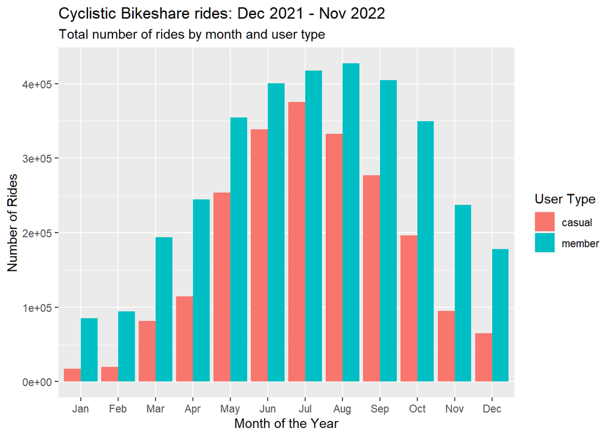

```r
all_trips_v2 %>%
  mutate(months = month(started_at, label = TRUE)) %>%
  group_by(member_type, months) %>%
  summarise(number_of_rides = n()) %>%
  arrange(member_type, months) %>%
  ggplot(aes(x = months, y = number_of_rides, fill = member_type)) +
  geom_col(position = "dodge") +
  labs(title = "Cyclistic Bikeshare rides: Dec 2021 - Nov 2022",
       subtitle = "Total number of rides by month and user type",
       x = "Month of the Year",
       y = "Number of Rides",
       fill = "User Type")
```

- The most popular usage months for casual riders are June, July, and August
- The most popular usage months for member riders are July, August, and September
- January is the month with the lowest number of rides for casual riders and member riders

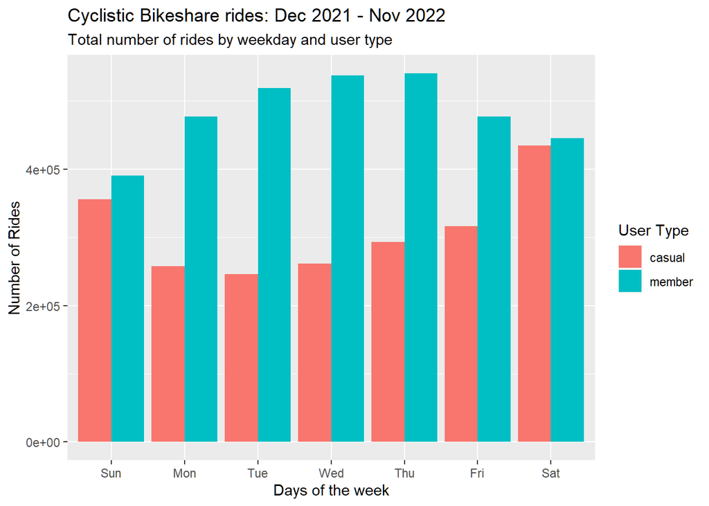

```r
all_trips_v2 %>%
  mutate(weekday = wday(started_at, label = TRUE)) %>%
  group_by(member_type, weekday) %>%
  summarise(number_of_rides = n()) %>%
  arrange(member_type, weekday) %>%
  ggplot(aes(x = weekday, y = number_of_rides, fill = member_type)) +
  geom_col(position = "dodge") +
  labs(title = "Cyclistic Bikeshare rides: Dec 2021 - Nov 2022",
       subtitle = "Total number of rides by weekday and user type",
       x = "Days of the week",
       y = "Number of Rides",
       fill = "User Type")
```

- The most popular usage days for casual riders are on the weekend
- The most popular usage days for member riders are on the weekday
- Tuesday has the lowest number of rides for casual riders

[output not shown]

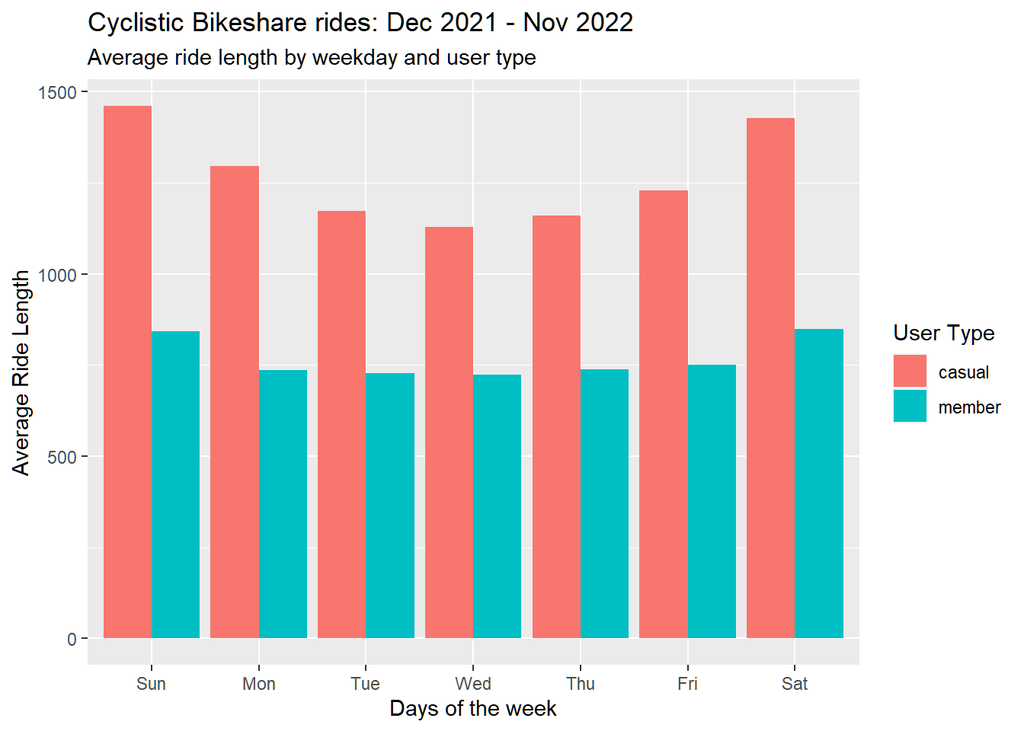

```r
all_trips_v2 %>%
  mutate(weekday = wday(started_at, label = TRUE)) %>%
  group_by(member_type, weekday) %>%
  summarise(number_of_rides = n(), average_ride_length = mean(ride_length)) %>%
  arrange(member_type, weekday) %>%
  ggplot(aes(x = weekday, y = average_ride_length, fill = member_type)) +
  geom_col(position = "dodge") +
  labs(title = "Cyclistic Bikeshare rides: Dec 2021 - Nov 2022",
       subtitle = "Average ride length by weekday and user type",
       x = "Days of the week",
       y = "Average Ride Length",
       fill = "User Type")
```

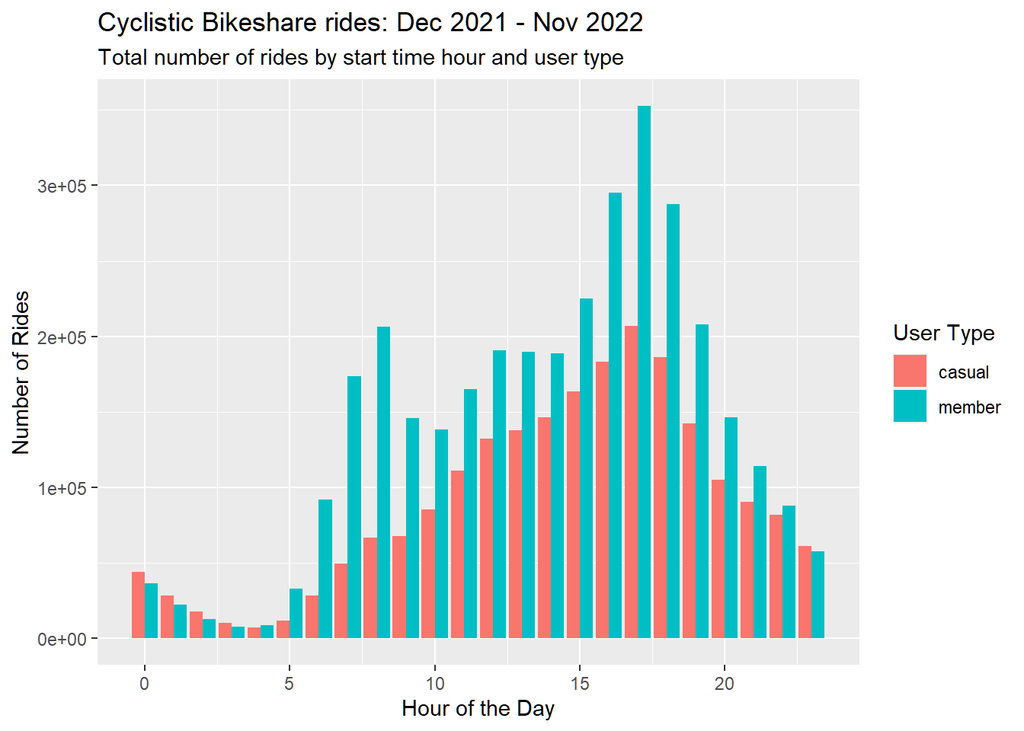

```r
all_trips_v2 %>%
  mutate(start_time_hour = hour(started_at)) %>%
  group_by(start_time_hour, member_type) %>%
  summarise(number_of_rides = n()) %>%
  arrange(start_time_hour) %>%
  ggplot(aes(x = start_time_hour, y = number_of_rides, fill = member_type)) +
  geom_col(position = "dodge") +
  labs(title = "Cyclistic Bikeshare rides: Dec 2021 - Nov 2022",
       subtitle = "Total number of rides by start time hour and user type",
       x = "Hour of the Day",
       y = "Number of Rides",
       fill = "User Type")
```

- The most popular time of the day for casual riders are in the afternoon
- The most popular time of the day for member riders are in the morning and afternoon

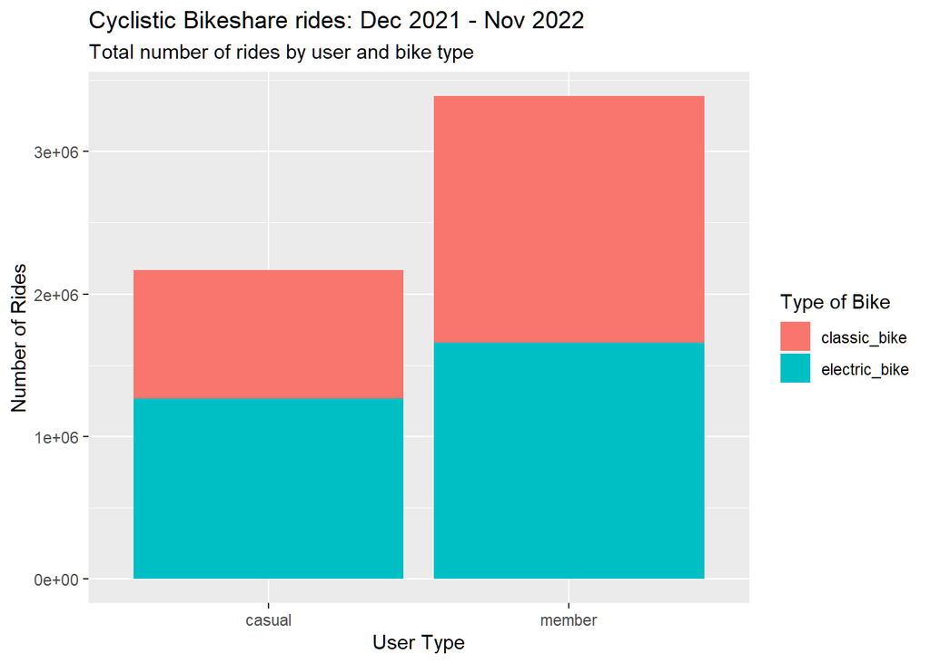

```r
all_trips_v2 %>%
  group_by(member_type, bike_type) %>%
  summarise(number_of_rides = n()) %>%
  arrange(member_type, bike_type) %>%
  ggplot(aes(x = member_type, y = number_of_rides, fill = bike_type)) +
  geom_col(position = "stack") +
  labs(title = "Cyclistic Bikeshare rides: Dec 2021 - Nov 2022",
       subtitle = "Total number of rides by user and bike type",
       x = "User Type",
       y = "Number of Rides",
       fill = "Type of Bike")
```

- The casual riders prefer to use electric bike than classic bike
- The member riders have a higher total number of rides in both types of bike than casual riders

##### **Recommendations**:

- The marketing campaign should be launched in June, July, and August weekends to attract more casual riders, given those are the most popular time casual riders use Cyclistic bikes
- Implement a limited time promotion for annual membership that loosens limits on Saturday and Sunday rides, given those are the most popular days casual riders use Cyclistic bikes
- Increase the number of electric bikes to inventory given casual riders prefer them over classic bikes